# Beverage consumption at a restaurant in Auckland

## Beverage consumption patterns at a boutique restaurant in Auckland CBD.

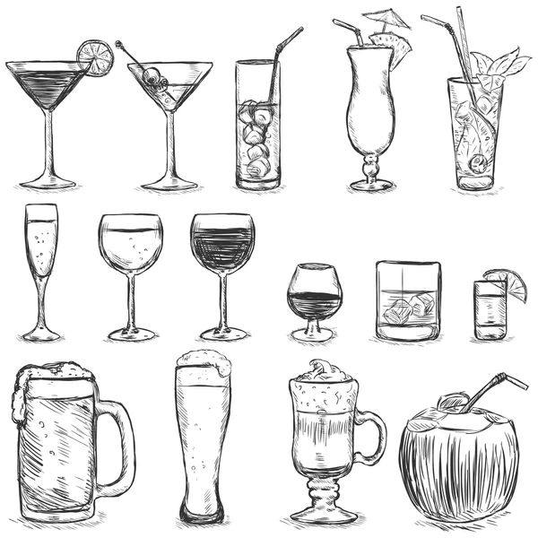

Intro

I was interested to see what factors might be in play for beverage consumption patterns at a fine restaurant in Auckland CBD.

I collected some data over 5 days, including factors such as age group, time of day, average spend of each table of individuals, and the dynamic of said persons at the table.

The average spend was calculated by total spend on beverages at a table, divided by number of individuals at the table.

## What did the average spend on beverages look like on each day of observation?

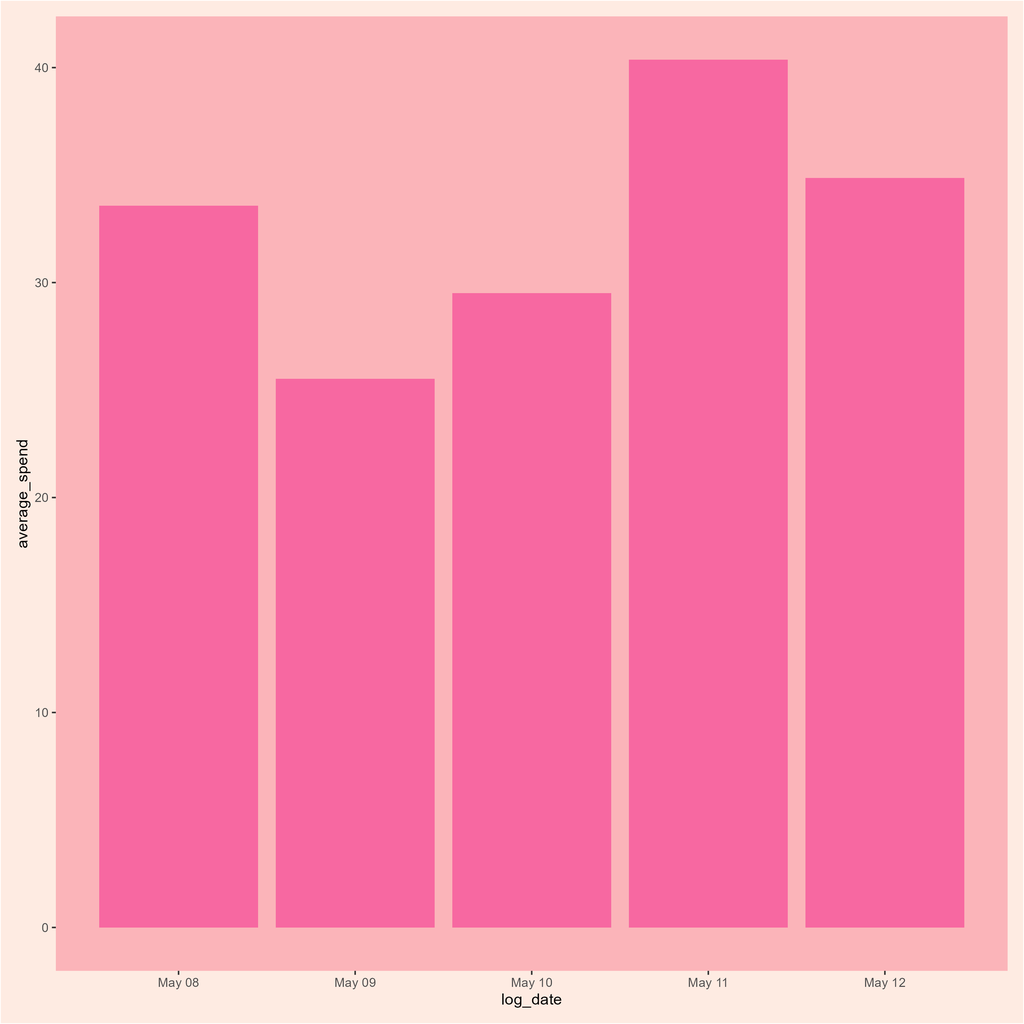

To my surprise, I observed that whether it is a weekday or weekend did not significantly affect the average spend on beverages. Another noticeable aspect was that the weekend (Fri 9th, Sat 10th) showed reduced expenses on beverages. Let’s have a look at potential factors of average spend on beverages.

## Time of day?

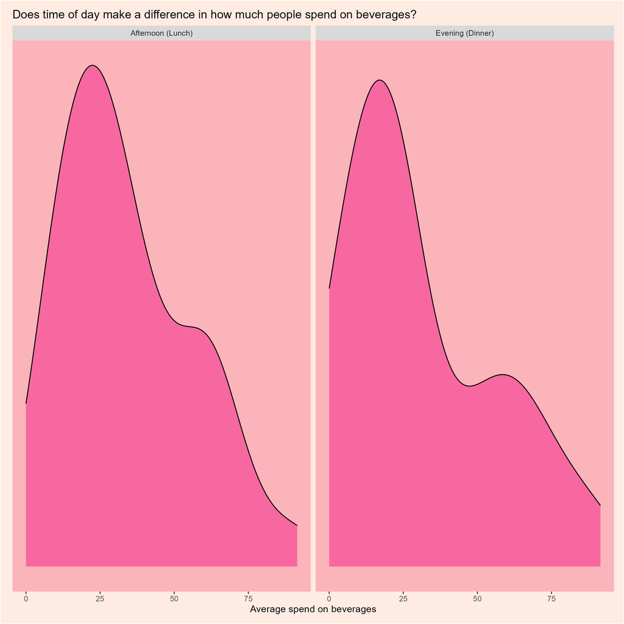

Doesn’t look much like there is a noticeable difference. Might everyone be equally happy to drink during lunchtime as dinnertime?

## Who were the people?

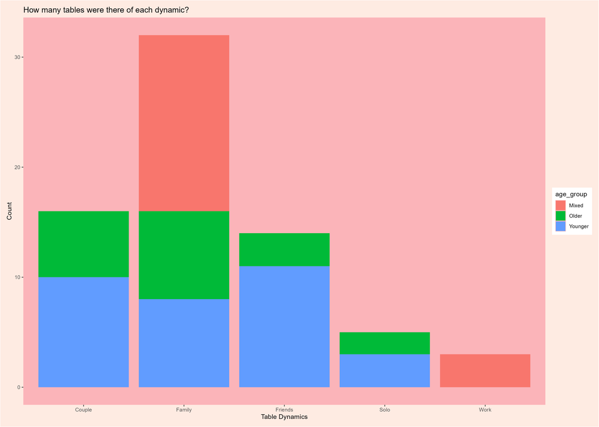

## How does each group drink?

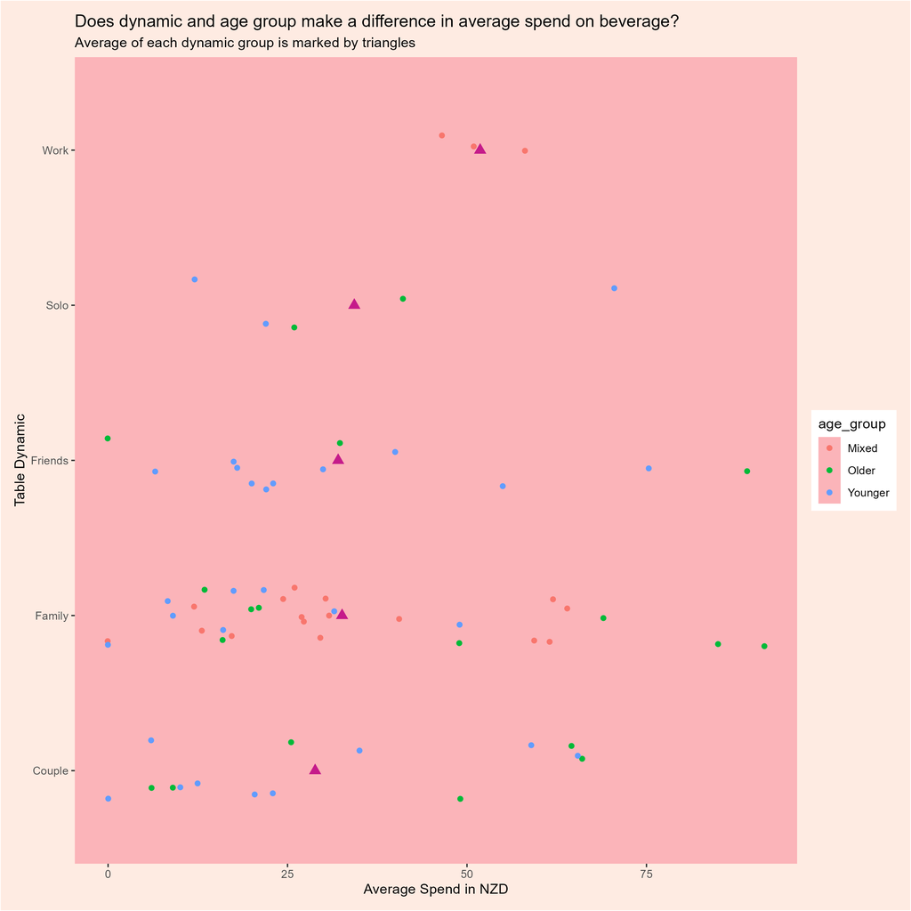

This might be a better way to look at the groups. We’re seeing some solid patterns:

- Work diners are always keen for a drink!
- Solo diners seem to follow their personal preferences.
- Friends tend to enjoy light drinks, obviously with exception.
- Families likewise, but if Dad is paying..?
- Couples are more conservative with their drinking, especially if they’re young.

```
{r file='data_visualisation.R', eval=FALSE, echo=TRUE}
```